# A. Lucas, Front. Phys. (2014) 掲載例題の解説 ー グラフの分割問題

本サンプルコードでは、論文 [A. Lucas, Front. Phys. (2014)](https://www.frontiersin.org/articles/10.3389/fphy.2014.00005/full) で紹介されている『グラフの分割問題』を Fixstars Amplify を用いて求解します。同論文に紹介されている他の NP 完全・NP 困難な問題も以下で解説しています。

## グラフ分割問題とは

$2N$ 個の頂点からなるグラフ $G$ があるとします。$G$ の頂点を $N$ 個ずつ 2 つの集合に分割する方法のうち、異なる集合に属する $2$ 点を結ぶ $G$ の辺の数が最小となるようなものを求める問題を **グラフ分割問題** といいます。

たとえば、以下のようなグラフにおいて、8 つの頂点をオレンジ色の 4 頂点の集合と青色の 4 頂点の集合に分割すると、青い頂点とオレンジ色の頂点を結ぶ辺は 2 本です。また、この分割の仕方が最適解であることも簡単に分かります。

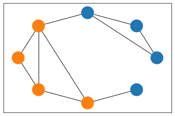

グラフ分割問題のより詳細な解説は[こちら](https://amplify.fixstars.com/ja/techresources/research/ising-model-formulation/graph-partitioning/)をご覧ください。

本サンプルプログラムでは、Fixstars Amplify を用いてグラフ分割問題を解くプログラムを作成します。定式化は [A. Lucas, Front. Phys. (2014)](https://www.frontiersin.org/articles/10.3389/fphy.2014.00005/full) の 2.2 節のものに沿って行います。

## 問題の作成

まず、例題として、NetworkX を用いて $2N$ 個の頂点を有するグラフ $G$ を作成します。

```python
import networkx as nx
import numpy as np

N = 4  # グラフの頂点数の半分
G = nx.Graph()
G.add_nodes_from(range(2 * N))
# 2つの頂点をつなぐ辺を定義
elist = [(0, 1), (0, 2), (1, 2), (2, 3), (3, 4), (3, 5), (3, 6), (4, 5), (5, 6), (6, 7)]
G.add_edges_from(elist)

pos = nx.circular_layout(G)

nx.draw_networkx(G, node_size=300, font_color="w", pos=pos)
```

[output not shown]

## 定式化

### 決定変数

グラフ $G$ の頂点数に等しい $2N$ 個のバイナリ変数 $q$ を $G$ の各頂点と対応させて、それぞれの頂点がどちらの集合に属するかを表すことにします。例えば、$q=0$ を青で示された頂点グループ、$q=1$ をオレンジで示された頂点グループとすると、以下のような分割の仕方に対応するバイナリ変数の組み合わせは下の表のようになります。

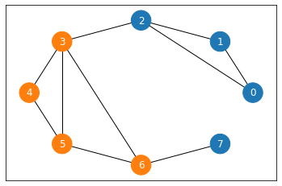

| 頂点のインデックス | 0 | 1 | 2 | 3 | 4 | 5 | 6 | 7 |
| --- | --- | --- | --- | --- | --- | --- | --- | --- |
| $q$ | 0 | 0 | 0 | 1 | 1 | 1 | 1 | 0 |

### 目的関数

グラフの分割問題を解くには、異なる集合に属する頂点同士を結ぶ辺の数を最小化するように決定変数 $q$ の値を決定すればよいです。

$G$ の頂点 $u$ と $v$ が異なる集合に属するには $q_u$ と $q_v$ の排他的論理和 (xor) が 1 になればよく、これは 2 次式で書くと $-2q_u q_v + q_u + q_v$ で表されます。辺で結ばれている頂点の組 $(u, v)$ すべてのうち、$u$ と $v$ が異なる集合に属するものの数が最小となればよいので、目的関数は

$$ \sum_{(u, v) \in E} \operatorname{xor}(q_u, q_v) = \sum_{(u, v) \in E} -2q_uq_v + q_u + q_v $$

で表すことができます。

### 制約条件

決定変数 $q$ が表す $G$ の頂点集合の分割が、頂点 $N$ 個からなる 2 つの集合への分割になっているためには、 $0$ となるバイナリ変数と $1$ となるバイナリ変数がそれぞれ $N$ 個ずつであることが必要十分です。 これは、

$$ \sum_{i = 0}^{2N-1}q_i = N $$

で表すことができます。

## 実装

上で作成した問題と定式化を使って、実際に問題を解いてみましょう。最初に、Fixstars Amplify の `BinarySymbolGenerator` を使ってバイナリ変数 $q$ を作成します。

```python
from amplify import BinarySymbolGenerator

gen = BinarySymbolGenerator()
q = gen.array(2 * N)
```

次に、目的関数 $\sum_{(u, v) \in E} \operatorname{xor}(q_u, q_v)$ を作成します。Fixstars Amplify のバイナリ変数には論理演算子がオーバーロードされていて、`q[u] ^ q[v]` で $\operatorname{xor}(q_u, q_v)$ と同じ値をとる 2 次多項式（$-2q_uq_v + q_u + q_v$）を計算することができます。

```python
cost = sum([q[u] ^ q[v] for u, v in G.edges])
```

続いて、制約条件を作成します。制約条件は、$2N$ 個のバイナリ変数の和がちょうど $N$ になるという条件でした。

```python
from amplify.constraint import equal_to

constraint = equal_to(q, N)
```

作成した目的関数と制約条件をまとめて論理模型に変換します。

```python
model = cost + constraint
```

クライアントを設定して、Amplify Annealing Engine で実行します。 `solve` の返り値が空でなければ、制約条件をみたす解が見つかったと分かります。

```python
from amplify.client import FixstarsClient
from amplify import Solver

client = FixstarsClient()
# client.token = "xxxxxxxxxxxxxxxxxxxxxxxxxxxxxxxx"  # ローカル環境等で使用する場合は、Fixstars Amplify AE のアクセストークンを入力してください。
client.parameters.timeout = 1000

# ソルバーを定義して実行
solver = Solver(client)
result = solver.solve(model)

if len(result) == 0:
    print("解が見つかりませんでした。")
else:
    print("解が見つかりました。")
```

[output not shown]

最後に、得られたグラフの分割を可視化します。

```python
values = q.decode(result[0].values)
colors = [f"C{int(value)}" for value in values]

nx.draw_networkx(G, node_size=600, node_color=colors, font_color="w", pos=pos)
```

[output not shown]